# Narrative_ AKA_MY_TG

## Section 4: Output 3

- Code for the Figure A8:

[output not shown]

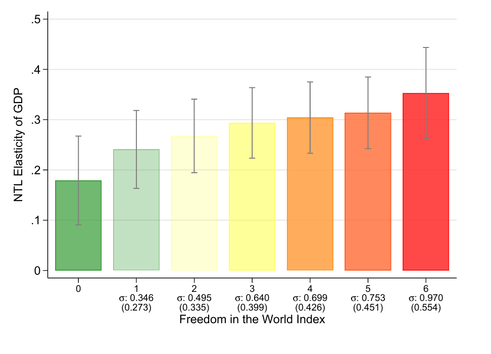

This bar chart illustrates the relationship between the Freedom in the World (FiW) Index and the elasticity of GDP to night-time lights (NTL). FiW index, a measure of political rights and civil liberties that ranges from 0 (most democratic) to 6 (most autocratic). The vertical axis shows the elasticity of GDP with respect to the night-time light activity. This measures how much reported GDP changes for a given change in night-time luminosity which serves as a proxy for economic activity. The height of the bars indicates the average NTL elasticity of GDP for countries with that FiW score. It can be seen that the elasticity increases steadily as countries become more authoritarian (higher FiW scores). This different type of political regime categorization demonstrates that in more democratic regimes, the NTL elasticity of GDP is lower, implying that less exaggeration in GDP reporting. In more autocratic regimes the NTL elasticity of GDP is higher which implies greater manipulation or overstatement of GDP relative to night-time light growth. The increasing trend aligns with the hypothesis that autocracies tend to overstate their GDP growth more than democracies.